# Self-Driving Car Engineer Nanodegree

## Project: Behavioral Cloning

**Author:** Bryan Rosales

**Date:** July 30 2017

My project includes the following files:

- model.ipynb containing the script to create and train the model
- drive.py for driving the car in autonomous mode
- model.h5 containing a trained convolution neural network
- writeup P3.html which is this file
- run4-48.mp4 containing the video with the car driving in autonomuos mode

## Project Description:

The goals / steps of this project are the following:

- Use the simulator to collect data of good driving behavior
- Build, a convolution neural network in Keras that predicts steering angles from images
- Train and validate the model with a training and validation data set
- Test that the model successfully drives around track one without leaving the road
- Summarize the results with a written report

## Pipeline Description

The pipeline proposed to the solution consisted of 4 steps:

1. Data Collection
2. Preprocessing and Data Augmentation
3. Model Architecture and Training
4. Testing the model in the Udacity Simulators

## Step 1: Data Collection, Analysis and Visualization

The data was collected using the Udacity windows version simluator. It was set in the lowest resolution '320x240' and the graphics quality 'Fastest'. The data collection process was the most dificult part of this project and therefore, I realized the importance of gathering quality data make a big difference in the results. In the beginning, I collected a couple laps in track1 using both directions and tried to fit the model with that data. However, the model had a high error (> 4.0) in both set (training and validation) and the car got outside the track. Then, my second approach was to put more focus in the data distribution and therefore I analyzed the data using a histogram and filtered curves and straight. For this I used a threshold of 0.15. Then, angles greater than 0.15 and less than -0.15 were called curves, the zero angles were named zeros, and the rest angles between -0.15 and 0.15 exclusive were called straight. Next, I generated more data based on the number of curves and straight and chose the amount of angles for each category (zeros, straight, left and right curves) looking for a uniform distribution. Eventhough the distribution was not completely uniform, the data was enoughly good to train the algorithm. The next table present the summary of the data distribution to the center camera:

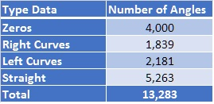

```python
from IPython.display import Image
Image(filename='Images/angles.jpg')
```

The histogram below displays the distribution of angles. If well there is a higher number of straight angle, it is explained because the track has a 70% aprox of straight sessions. However, the important part is that the numbers of curves for left and right was increased proportionally. It made that the car was not biased for any side. The histogram includes only the angles for the center camera.

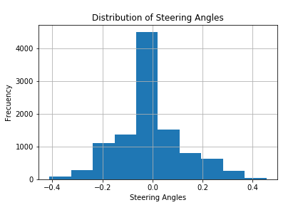

```python
Image(filename='Images/Hist.png')
```

## Step 2: Preprocessing and Data Augmentation

The strategy to data augmentation basically was:

**1. Cameras:** I used the 2 additional images provided by left and right cameras and adding a correction factor of 0.06 to those angles. The number of images availables to train and validate the model increased from 13,283 to 39,849. Using those images left and right was not neccesary to create recovery picture.

**2. Brightness:** The images brightness were changed randomly with a 0.5 probability. For that, the image was converted to HSV format then the layer 'v' was multiply by a random factor between 0.5 and 1. This method produced images with different brightness which help the model to generalize.

**3. Flipping:** Only to the center images with absolute angles greater than 0.4 was applied flipping method. The idea was to generate new images since center camera avoiding the model to be biased.

Preprocessing: **- Image Size:** 160x320x3 **- Data Generator:** The model used two data generators which receive the batch size wished and return such size of images applying all the previous methods mentioned. The next is a sample of 8 images randomly chosen after preprocessing stage:

```
images Shape:  (150, 160, 320, 3)
steering Shape:  (150,)
(150, 160, 320, 3)
```

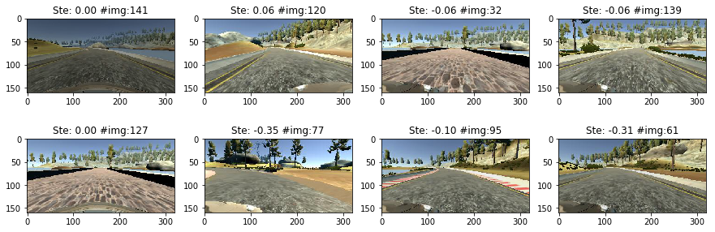

```python
print('images Shape: ', x1.shape)
print('steering Shape: ', y1.shape)
displayImg(x1, y1)
```

## Step 3: Model Architecture and Training

### Setup Hyperparameters

- EPOCHS = 3
- BATCH_SIZE = 150
- Optimizer = Adam

The architecture base used for this project was NVidia with a few changes:

- 5 Convolutional Layers
- 1 Flatten Layer
- 4 Fully Connected
- The python package used was keras Here the description for each layer:

model = Sequential()

## Input

The Project 3 architecture accepts a 160x320x3 images as input, where 3 indicates that the image is in color, 160 pixels height and 320 pixels width.

## Preprocessing Layer

- The images were cropped to capture the interested zone on which the model should learn to predict the angle. Then a cropping function is applyed and as a result the output is a image with shape (65,320,3). Also, the cropping helps the algorithm to be faster because the image contains less pixeles.

  model.add(Cropping2D(cropping=((70,25), (0,0)), input_shape=(160,320,3)))
- The second part is to normalize the image setting a mean 0 and range between -0.5 to 0.5.

  model.add(Lambda(lambda x: x / 255.0 - 0.5))

## Layer 1 to 3:

Three convolutional layers with a kernel=5x5, Stride=2x2, Activation='Relu', Padding='Valid'

```
model.add(Conv2D(24,5,strides=2,activation='relu', padding='valid'))
model.add(Conv2D(36,5,strides=2,activation='relu', padding='valid'))
model.add(Conv2D(48,5,strides=2,activation='relu', padding='valid'))
```

## Layer 4 to 5:

Two convolution layers with a kernel=3x3, Activation='Relu', Padding='Valid' model.add(Conv2D(64,3,activation='relu', padding='valid')) model.add(Conv2D(64,3,activation='relu', padding='valid'))

## Layer 6:

One flatten layer model.add(Flatten())

### Output

One fully connected with output 1, where 1 indicates the steering angle calculated by the network model.add(Dense(1))

The optimizer used was Adam therefore the learning rate was not tuned manually. The loss was measured using 'mse' because of the output to predict is a numeric value.

Also, the keras fit_generator was used in order to processing batch size without having the total images loaded in RAM. The generator improved the performance of the algorithm signicantly.

model.compile(loss='mse', optimizer= 'adam')

history_object = model.fit_generator(trainingGen, steps_per_epoch=math.ceil(len(tPaths)/batchSize), epochs=3, verbose=1,

validation_data=validGen, validation_steps=math.ceil(len(vPaths)/batchSize), initial_epoch=0)

### Training and Testing Results

During several attempts to reduce overfitting and underfitting, I tried l2 generalization and dropping layers. However, I did see for sustantial improvement. Instead, I was more on focus in the quality of the data and tunning basically 2 parameteres correction (0.06) factor for lateral cameras and flipping angles selected.

In the begining, the car was driving out of the track on the curves, but capturing more specialized data on the curves, I was able to correct the issue. Next, I was focus on correct the oscillation on the track. For that, I tunned the previous parameters: angles correction on sides cameras and the parameter to flip the image. As a consequence, I achieved to reduce the oscillations on track and improve the way how the car drove on the curves.

The model was trained and validated on different data sets. I splited the data using 80% for training and 20% for validation. The model was tested by running it through the simulator and ensuring that the vehicle could stay on the track.

- Training Time: 1052 seconds (17.5 Minutes)
- Training loss: 0.0046
- Validation loss: 0.0044

The losses in both sets look to be low. The results do not present underfitting or overfitting symptoms

Epoch 1/3 71/71 [==============================] - 367s - loss: 0.0115 - val_loss: 0.0055

Epoch 2/3 71/71 [==============================] - 342s - loss: 0.0050 - val_loss: 0.0049

Epoch 3/3 71/71 [==============================] - 343s - loss: 0.0046 - val_loss: 0.0044

Done...

The next is the graph of the means square errors. In the first epoch is possible to observe the highest decrement in the training set and the next 2 epoch the algorithm converged in both set to 0.004.

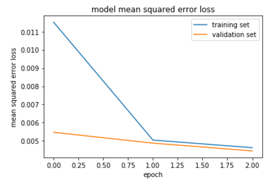

```python
Image(filename='Images/square errors.png')
```

At the end of the process, the vehicle is able to drive autonomously around the track without leaving the road. There are a couple oscillation but it does not affect the security of the passenger.

### Conclusions

1. Amazing project, I have learnt too much on this. My first and the most important conclusion is the importance on the data quality process. I spent 70% of the project aprox improving the data. I had to go back several times to collect more data and filtering it to create something similar to an uniform distribution. In my prospection, the data is the most important element because it allows that the network can extract the information needed to fit correctly.
2. The use of 3 cameras rather than 1 allowed the network generalize in a better way helping the car to stay on the center.
3. I tried to configure the cloud services like AWS, Paperspace and Floyd. I had problems on versions and parameters setting. Therefore, I had to train the model in my CPU and sometimes it was very frustrating because of the time. My conclusion is that even though I achieved to reach a good performance, projects like this require use of GPU power.